# Graded Exercise 3

Frieda Krois

2025-06-05

## Exercise 1: Initializing git (4 Points)

For this whole exercise sheet we will be tracking all our changes to it in git.

1. Start by initializing a new R project with git support, called `2025-exeRcise-sheet-3`. If you forgot how to do this, you can follow this [guide](https://malikaihle.github.io/Introduction-RStudio-Git-GitHub/rstudio_project.html).
2. Commit the files generated by Rstudio.
3. For all of the following tasks in this exercise sheet we ask you to always commit your changes after finishing each subtask e.g. create a commit after task *1d*, *1e* etc.

> Note: This applies only to answers that have text or code as their answer. If you complete tasks in a different order or forget to commit one, this is no problem. If you change your answers you can just create multiple commits to track the changes.
4. Name 2 strengths and 2 weaknesses of git. (Don’t forget to create a commit after this answer, see *1c*)

*Strengths and weaknesses of git*

**strenghts:**

- convenient and fast for collaboration
- version control makes it almost impossible to lose files

**weeknesses:**

- can be tricky to use (especially in the beginning)
- requires explicit use (does not work in the background)
5. Knit this exercise sheet. Some new files will automatically be generated when knitting the sheet e.g. the HTML page. Ignore these files, as we only want to track the source files themselves. You can, but don’t need to create a `.gitignore` file. Just do not commit these files manually.

## Exercise 2: Putting your Repository on GitHub (3 Points)

For this task you will upload your solution to GitHub.

1. Create a new repository on GitHub in your account named `exeRcise-sheet-3`. Make sure you create a **public repository** so we are able to see it for grading. Add the link to the repository below: >https://github.com/Friedikr/exeRcise-sheet-3<
2. Push your code to this new repository by copying and executing the snippet on github listed under `…or push an existing repository from the command line`.
3. Regularly push your latest changes to GitHub again and especially do so when you are finished with this sheet.

## Exercise 3: Pixar Films (4 Points)

Download the `pixar_films` and `public_response` datasets from the GitHub repository and track them in git.

Link: https://github.com/rfordatascience/tidytuesday/tree/main/data/2025/2025-03-11

For small datasets like these adding them to git is not a problem.

1. Load the `pixar_films` dataset into R. Clean the dataset by removing films without a title. Inspect the variable `film_rating`. What are the possible values and what do they mean? Create a factor variable for the film rating. Why is this appropriate?

```r
# load library
library(tidyverse)
# load data
films <- read_csv("data/pixar_films.csv")
head(films)
```

```
## # A tibble: 6 × 5
##   number film            release_date run_time film_rating
##    <dbl> <chr>           <date>          <dbl> <chr>
## 1      1 Toy Story       1995-11-22         81 G
## 2      2 A Bug's Life    1998-11-25         95 G
## 3      3 Toy Story 2     1999-11-24         92 G
## 4      4 Monsters, Inc.  2001-11-02         92 G
## 5      5 Finding Nemo    2003-05-30        100 G
## 6      6 The Incredibles 2004-11-05        115 PG
```

```r
# clean dataframe
films_clean <- films %>%
  filter(!is.na(film), film != "")
```

```r
# change variable film rating to factor
films_clean$film_rating <- factor(
  films_clean$film_rating,
  levels = c("G", "PG"),
  ordered = TRUE
)
```

The possible values are G (Rated G: General audiences - all ages admitted), PG (arental guidance suggested – Some material may not be suitable for children) and not rated. In addition we have three N/A’s (missing/ unspecified values). A factor variable is appropriate because a factor is ideal for categorical data — like film ratings — especially when values are from a known, limited set and may have a natural order which is the case here: film_rating represents categories not numeric quantities and we have a fixed set of possible values (here I just take “interesting values” “G” and “PG” into account).

2. Inspect the film titles manually. Which films form a film series? A film series can be identified by a common word in the titles of the films, often in conjunction with a number in the title, e.g. “Despicable Me” and “Despicable Me 2”. Create a dataframe which displays a list of the different series with the titles of the films and how many films belong to the series. Output the dataframe.

```r
library(dplyr)
library(stringr)

# Funktion: Erster sinnvoller Begriff im Titel (außer "The", "A", ...)
get_series_name <- function(title) {
  words <- str_split(tolower(title), "\\s+")[[1]]
  words <- words[!words %in% c("the", "a", "and", "of", "in", "to")]
  words <- words[!str_detect(words, "^[0-9]+$")]
  if (length(words) > 0) return(str_to_title(words[1]))
  return(NA)
}

# Wende Funktion auf saubere Titelliste an
films_series_summary <- films_clean %>%
  mutate(series_name = sapply(film, get_series_name)) %>%
  filter(!is.na(series_name)) %>%
  group_by(series_name) %>%
  filter(n() > 1) %>%
  summarise(
    film_titles = paste0("[", paste0("'", film, "'", collapse = ", "), "]"),
    film_count = n(),
    .groups = "drop"
  ) %>%
  arrange(desc(film_count))

print(films_series_summary, row.names = FALSE)
```

```
## # A tibble: 4 × 3
##   series_name film_titles                                             film_count
##   <chr>       <chr>                                                        <int>
## 1 Toy         ['Toy Story', 'Toy Story 2', 'Toy Story 3', 'Toy Story…          4
## 2 Cars        ['Cars', 'Cars 2', 'Cars 3']                                     3
## 3 Finding     ['Finding Nemo', 'Finding Dory']                                 2
## 4 Incredibles ['The Incredibles', 'Incredibles 2']                             2
```

3. Load the `public_response` dataframe into R. Convert the `cinema_score` variable into a factor while ensuring the factor levels are defined in ascending order, from the lowest to the highest score. Combine `public_response` with the `pixar_films` dataset using an appropriate merge variable.

```r
public_response <- read_csv("data/public_response.csv")
head(public_response)
```

```
## # A tibble: 6 × 5
##   film            rotten_tomatoes metacritic cinema_score critics_choice
##   <chr>                     <dbl>      <dbl> <chr>                 <dbl>
## 1 Toy Story                   100         95 A                        NA
## 2 A Bug's Life                 92         77 A                        NA
## 3 Toy Story 2                 100         88 A+                      100
## 4 Monsters, Inc.               96         79 A+                       92
## 5 Finding Nemo                 99         90 A+                       97
## 6 The Incredibles              97         90 A+                       88
```

```r
# cinema_score in geordneten Faktor umwandeln mit Levels A- < A < A+
levels_ordered <- c("A-", "A", "A+")

public_response$cinema_score <- factor(public_response$cinema_score,
                                      levels = levels_ordered,
                                      ordered = TRUE)



#  Merge der beiden Datensätze über die Spalte "film"
combined_data <- merge(films_clean, public_response, by = "film", all = TRUE)

head(combined_data)
```

```
##           film number release_date run_time film_rating rotten_tomatoes
## 1 A Bug's Life      2   1998-11-25       95           G              92
## 2        Brave     13   2012-06-22       93          PG              78
## 3         Cars      7   2006-06-09      117           G              74
## 4       Cars 2     12   2011-06-24      106           G              40
## 5       Cars 3     18   2017-06-16      102           G              69
## 6         Coco     19   2017-11-22      105          PG              97
##   metacritic cinema_score critics_choice
## 1         77            A             NA
## 2         69            A             81
## 3         73            A             89
## 4         57           A-             67
## 5         59            A             66
## 6         81           A+             89
```

4. Choose one of the variables representing the public response and create a bar plot for the films belonging to a series. Here are the details of the plot:
   - The film series are represented on the x-axis.
   - Your chosen public response variable is displayed on the y-axis.
   - Each film in the series is represented as a separate bar. Bars are grouped by film under their respective series on the x-axis. Order the bars within a series according to the release date of the films.
   - A title and axis labels for context.

   What do you notice when comparing the scores of the films in a series? Do you see any patterns?

```r
get_series_name <- function(title) {
  words <- str_split(tolower(title), "\\s+")[[1]]
  words <- words[!words %in% c("the", "a", "and", "of", "in", "to")]
  words <- words[!str_detect(words, "^[0-9]+$")]
  if (length(words) > 0) return(str_to_title(words[1]))
  return(NA)
}

# Step 2: Add series_name column
combined_data <- combined_data %>%
  mutate(series_name = sapply(film, get_series_name))

# Step 3: Keep only series with more than one film
combined_data <- combined_data %>%
  group_by(series_name) %>%
  filter(n() > 1) %>%
  ungroup()

# Step 4: Add release order manually (adjust if needed)
combined_data <- combined_data %>%
  mutate(release_order = case_when(
    film == "Toy Story" ~ 1,
    film == "Toy Story 2" ~ 2,
    film == "Toy Story 3" ~ 3,
    film == "Toy Story 4" ~ 4,
    film == "Cars" ~ 1,
    film == "Cars 2" ~ 2,
    film == "Cars 3" ~ 3,
    film == "The Incredibles" ~ 1,
    film == "Incredibles 2" ~ 2,
    film == "Monsters, Inc." ~ 1,
    film == "Monsters University" ~ 2,
    film == "Finding Nemo" ~ 1,
    film == "Finding Dory" ~ 2,
    TRUE ~ NA_real_
  )) %>%
  filter(!is.na(release_order))
```

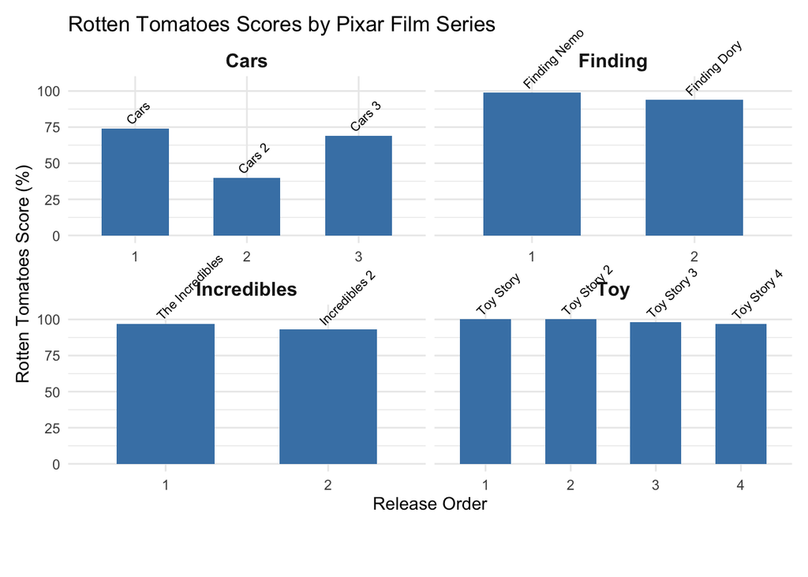

```r
ggplot(combined_data, aes(x = factor(release_order), y = rotten_tomatoes)) +
  geom_bar(stat = "identity", fill = "steelblue", width = 0.6) +
  geom_text(aes(label = film), vjust = -0.5, size = 2.8, angle = 45, hjust = 0) +
  facet_wrap(~ series_name, scales = "free_x") +
  labs(
    title = "Rotten Tomatoes Scores by Pixar Film Series",
    x = "Release Order",
    y = "Rotten Tomatoes Score (%)"
  ) +
  theme_minimal() +
  theme(
    axis.text.x = element_text(angle = 0, hjust = 0.5),
    strip.text = element_text(face = "bold", size = 12),
    plot.margin = margin(t = 10, r = 10, b = 40, l = 10)  # mehr Platz unten
  ) +
  ylim(0, 105) +
  coord_cartesian(clip = "off")
```

I notice that in all four series the first film got the highest scores. The following films of the series could not beat the popularity score of the debut film. Especially in Cars there is a big difference between film 1 and 2.

## Exercise 4: Open Analysis (4 points)

This exercise is a bit more open-ended. You can choose any dataset from [Our World in Data](https://ourworldindata.org/) and analyze it, while determining the research question yourself.

1. Go to https://github.com/owid/owid-datasets/tree/master/datasets and choose a dataset that interests you. You can have a look at https://ourworldindata.org/ to gather some inspiration.
2. Download the dataset and track it in git.

```r
data <- read_csv("data/Missing_women_estimates.csv")
head(data)
```

```
## # A tibble: 6 × 5
##   Entity  Year Missing Females (Bongaarts & Guilmoto, 2…¹ Excess female deaths…²
##   <chr>  <dbl>                                      <dbl>                  <dbl>
## 1 China   1970                                   27200000                     NA
## 2 China   1975                                   29000000                 320000
## 3 China   1980                                   31800000                 420000
## 4 China   1985                                   33200000                 500000
## 5 China   1990                                   39200000                 570000
## 6 China   1995                                   44300000                 540000
## # ℹ abbreviated names: ¹`Missing Females (Bongaarts & Guilmoto, 2015)`,
## #   ²`Excess female deaths (Bongaarts & Guilmoto, 2015)`
## # ℹ 1 more variable: `Missing female births (Bongaarts & Guilmoto, 2015)` <dbl>
```

3. Put the name / title of the dataset and a link to it below.
- Dataset Name: Missing women estimates (Bongaarts & Guilmoto, 2015)
- Link: https://github.com/owid/owid-datasets/tree/master/datasets/Missing%20women%20estimates%20(Bongaarts%20%26%20Guilmoto%2C%202015)
4. Come up with a (research) question you want to answer with the data and briefly explain why you believe this is an interesting question within one sentence. It should be a question that can be answered with the dataset and using R.

Research topic: The term “missing women” indicates a shortfall in the number of women relative to the expected number of women in a region or country. Missing female births and excess female mortality are calculated based on the difference between observed and expected sex ratios. It is theorized to be caused by sex-selective abortions, female infanticide, and inadequate healthcare and nutrition for female children. Due to that matter I want to reseach the role of China and India when it comes to missing women worldwide. The dataset gives data for China, Indi, World and Rest of the World from 1970 to today in five-year intervals, with projections through to 2050.

Research question: “What role do China and India play in the global pattern of gender-based demographic inequality, as reflected in the distribution of missing women?”

5. Use R to answer your chosen question. Please limit your analysis to the functions and techniques we have covered so far in the course. You are **not expected** to use advanced statistical models or external packages which haven’t been introduced.

```r
colnames(data) <- c("Country", "Year", "Missing_Females", "Excess_Deaths", "Missing_Births")

# data wrangling
data_filtered <- data %>%
  select(Country, Year, Missing_Females)

data_wide <- data_filtered %>%
  pivot_wider(names_from = Country, values_from = Missing_Females)

data_wide <- data_wide %>%
  mutate(
    China_Share = China / World,
    India_Share = India / World,

  )

share_long <- data_wide %>%
  select(Year, China_Share, India_Share) %>%
  pivot_longer(cols = c(China_Share, India_Share),
               names_to = "Country", values_to = "Share") %>%
  mutate(Country = recode(Country,
                          "China_Share" = "China",
                          "India_Share" = "India",
                        ))
```

6. Create a meaningful plot / figure with the dataset. Make sure to provide a figure caption (via the chunk options / Rmarkdown) and correctly label the figure.

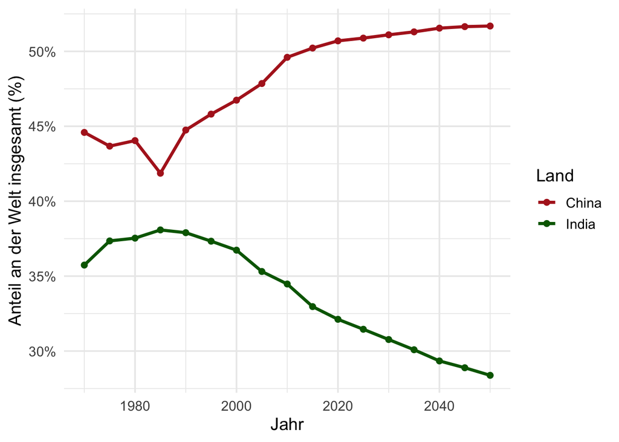

Proportion of missing women from China and India in the global total

```r
# (Hier kommt dein Plot-Code)
ggplot(share_long, aes(x = Year, y = Share, color = Country)) +
  geom_line(size = 1.2) +
  geom_point(size = 2) +
  scale_y_continuous(labels = scales::percent_format(accuracy = 1)) +
  scale_color_manual(values = c("firebrick", "darkgreen")) +
  labs(
    x = "Jahr",
    y = "Anteil an der Welt insgesamt (%)",
    color = "Land"
  ) +
  theme_minimal(base_size = 14)
```

## Final Note

Make sure to push all your commits and changes to GitHub before submitting the exercise sheet.